# Final-Project

Silas Raye

2023-11-28

# Project Overview:

My project aims to predict the market prices of Magic: The Gathering (MTG) cards based on their in-game utility and attributes. This project not only aligns with my personal interests but also presents a unique opportunity to apply high-dimensional data analysis in a real-world context.

### Data Source:

To ensure the reliability and accessibility of my data, I plan to utilize datasets from [Scryfall](https://scryfall.com/docs/api/bulk-data), a comprehensive and regularly updated source for MTG card information. These datasets offer detailed insights into each card’s attributes and, importantly, are readily available and well-structured for analysis.

### Hypothesis:

The underlying hypothesis of my project is that the market value of MTG cards is primarily influenced by their playability in the game. I intend to examine various factors, such as card type, abilities, and inclusion in online decklist, to determine their correlation with market pricing.

### Methodology:

Leveraging the high-dimensional nature of the dataset, I plan to apply the various methods we have learned including lasso regression, ridge regression, principal component regression, and partial least squares. This is, of course, a tentative list. I will have to see how well different methods perform on my actual data as the project progresses.

### Significance:

This project is not only a fascinating exploration into the intersection of data science and gaming but also has practical implications for players and collectors in understanding and predicting market trends.

[figure not shown]

| name | cmc | oracle_text | power | toughness | reserved | booster | edhrec_rank |
| --- | --- | --- | --- | --- | --- | --- | --- |
| “Ach! Hans, Run… | 6 | At the beginnin… | 0 | 0 | 0 | 1 | 0 |
| “Brims” Barone,… | 5 | When “Brims” Ba… | 5 | 4 | 0 | 1 | 24238 |
| “Rumors of My D… | 3 | {3}{B}, Exile a… | 0 | 0 | 0 | 1 | 0 |
| +2 Mace | 2 | Equipped creatu… | 0 | 0 | 0 | 1 | 13735 |
| A Display of My… | 0 | When you set th… | 0 | 0 | 0 | 0 | 0 |

| loyalty | legal_in_standard | legal_in_pioneer | legal_in_modern | legal_in_commander | price | duplicate_count | num_colors |
| --- | --- | --- | --- | --- | --- | --- | --- |
| 0 | 0 | 0 | 0 | 0 | 3.32 | 1 | 2 |
| 0 | 0 | 0 | 0 | 0 | 0.02 | 4 | 2 |
| 0 | 0 | 0 | 0 | 0 | 0.09 | 1 | 1 |
| 0 | 0 | 1 | 1 | 1 | 0.02 | 1 | 1 |
| 0 | 0 | 0 | 0 | 0 | 12.47 | 1 | 0 |

| raritycommon | raritymythic | rarityrare | rarityspecial | rarityuncommon | type_categoryArtifact | type_categoryCreature | type_categoryEnchantment |
| --- | --- | --- | --- | --- | --- | --- | --- |
| 0 | 0 | 1 | 0 | 0 | 0 | 0 | 1 |
| 0 | 0 | 0 | 0 | 1 | 0 | 1 | 0 |
| 0 | 0 | 0 | 0 | 1 | 0 | 0 | 1 |
| 1 | 0 | 0 | 0 | 0 | 1 | 0 | 0 |
| 1 | 0 | 0 | 0 | 0 | 0 | 0 | 0 |

| type_categoryInstant | type_categoryLand | type_categoryOther | type_categoryPlaneswalker | type_categorySorcery | type_categoryToken | year |
| --- | --- | --- | --- | --- | --- | --- |
| 0 | 0 | 0 | 0 | 0 | 0 | 2004 |
| 0 | 0 | 0 | 0 | 0 | 0 | 2022 |
| 0 | 0 | 0 | 0 | 0 | 0 | 2017 |
| 0 | 0 | 0 | 0 | 0 | 0 | 2021 |
| 0 | 0 | 1 | 0 | 0 | 0 | 2010 |

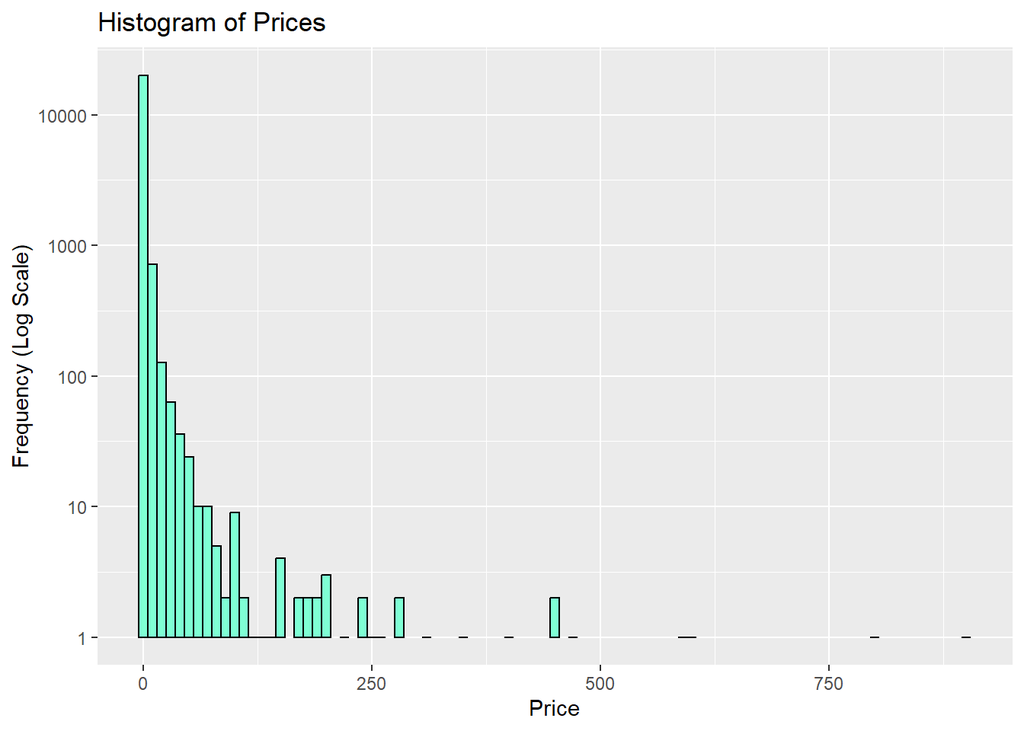

# Different NLP Techniques

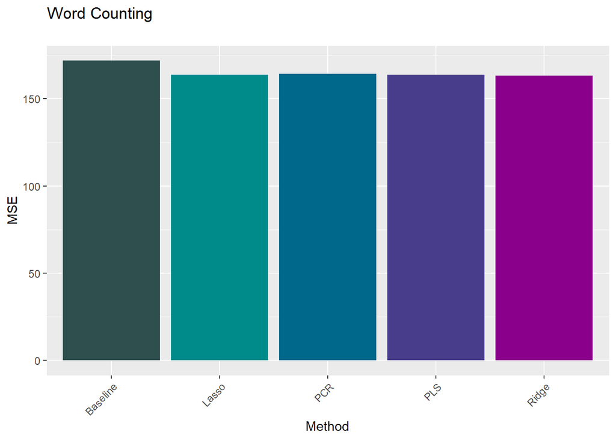

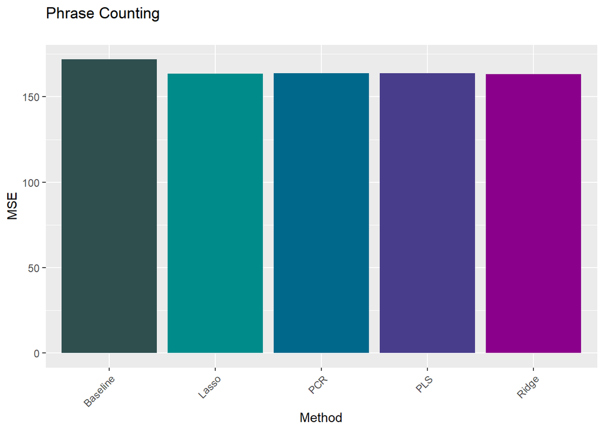

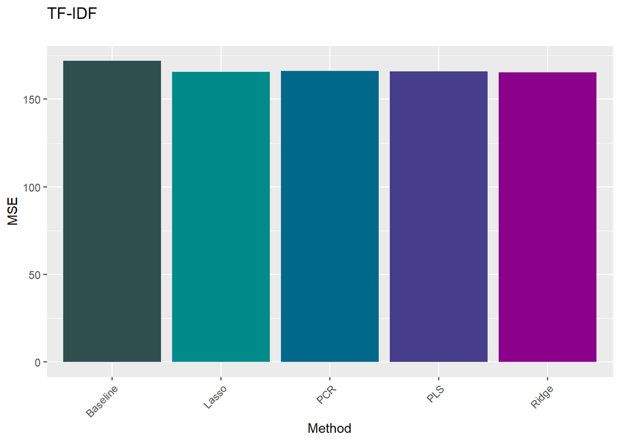

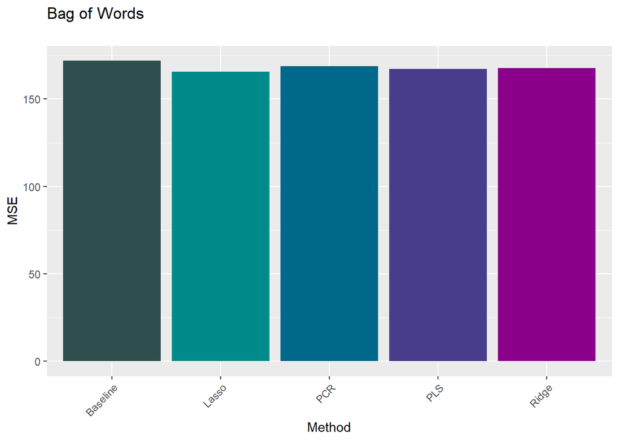

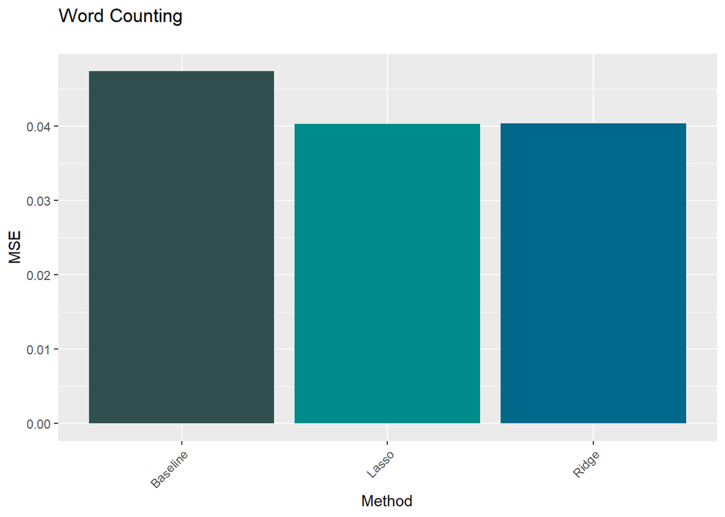

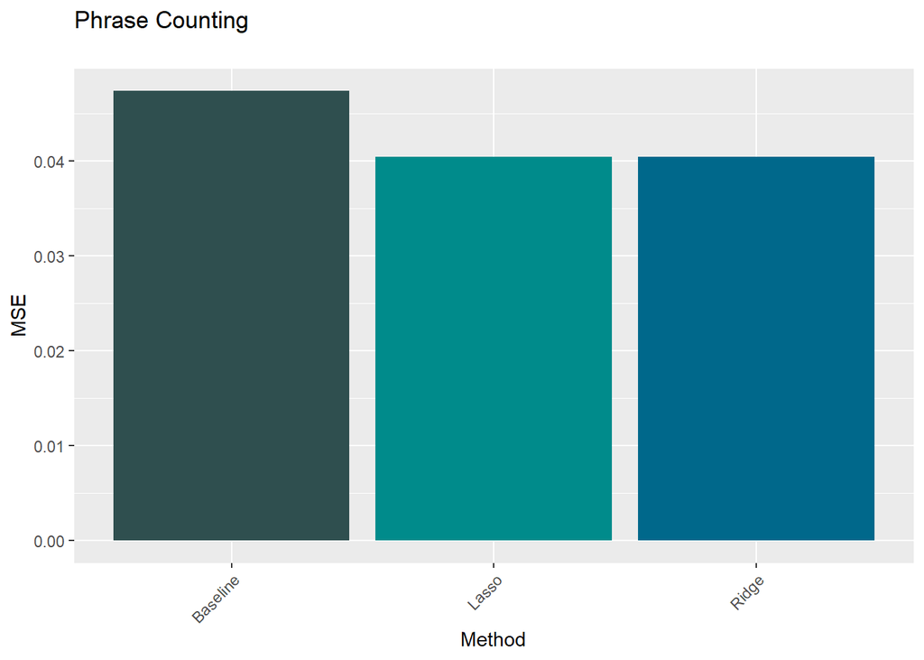

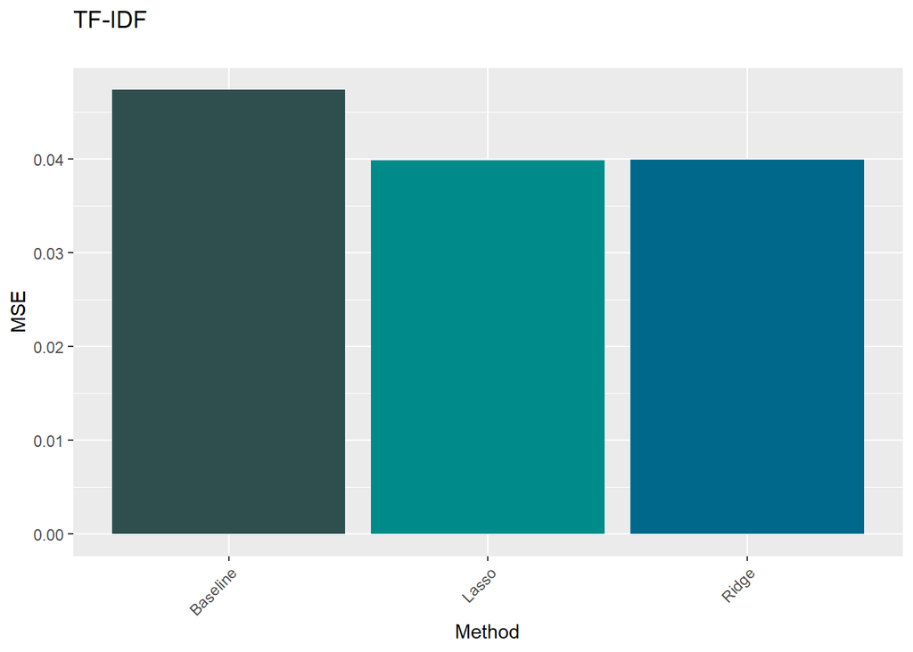

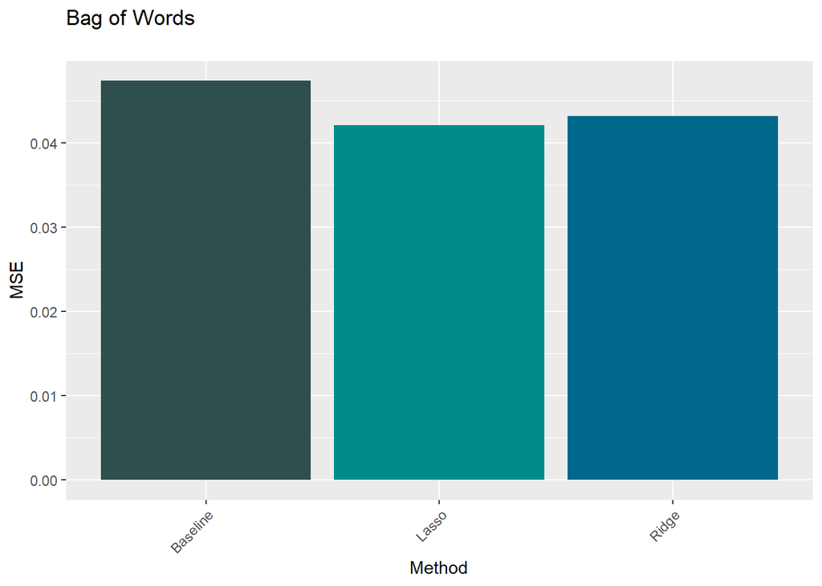